# Informe B&C

Juan José Aguado

13-02-2024

## 1. Introducción

El presente es un análisis estadístico sobre los datos de las viviendas de Cali en el cual se tiene en cuenta las características de las distintas casas o apartamentos tales como precio y ubicación con el fin de entregarle información útil a los directivos de B&C para poder tomar decisiones informadas con respecto al creciente mercado inmobiliario.

## 2. Objetivos

Los siguientes son objetivos que permitiran hacer un analisis estadistico para las decisiones de los directivos de B&C:  
1. Exponer el tipo de viviendas más ofertadas en Cali.  
2. Encontrar las características más relevantes de la oferta de vivienda en Cali.  
3. Encontrar correlaciones entre las distintas variables como el precio, la zona, área construida, entre otras.  
4. Mostrar el precio de las viviendas en distintas zonas de Cali.  
5. Encontrar patrones e información útil para la toma de decisiones de los directivos de B&C.

## 3. Métodos

Habrá distintos métodos para satisfacer la finalidad de cada objetivo y serán los siguientes:

#### 1. Exponer el tipo de viviendas más ofertadas en Cali.

- Tablas de frecuencia del tipo de vivienda.
- Tablas de frecuencia relativa del tipo de vivienda en cada zona.
- Gráfico de barras por tipo de vivienda en las distintas zonas de Cali.
- Gráfico de pastel para la cantidad de viviendas por zonas.

#### 2. Encontrar las características más relevantes de la oferta de vivienda en Cali.

- Indicadores de posición para las variables de precio y área construida.
- Gráficas para las variables precio, área construida y estrato.

#### 3. Encontrar correlaciones entre las distintas variables.

- Gráfica de dispersión entre área y precio..

#### 4. Mostrar el precio de las viviendas en distintas zonas de Cali.

- Indicadores de centro y dispersión del precio por cada zona de Cali.

#### 5. Encontrar patrones e información útil para la toma de decisiones de los directivos de B&C.

- Limpieza y análisis de datos faltantes.
- Análisis de inferencia estadística a partir de la información recolectada en los resultados.

## 4. Resultados

Los resultados que salieron de los métodos por objetivos son los siguientes:

#### 1. Exponer el tipo de viviendas más ofertadas en Cali.

El tipo de vivienda más ofertada son los apartamentos predominando con un 61.29% en comparación al 38.71% de las casas. Sin embargo, no en todas las zonas de Cali predominan los apartamentos ya que en la zona del centro y la zona oriente hay más casas. En las zonas donde hay más casas hay muy pocos apartamentos, en el centro solo el 19.35% son apartamentos y en el oriente solo el 17.66%, el oeste en cambio es el caso contrario con 85.89% de las viviendas siendo apartamentos, el norte y el sur están más equilibrados teniendo en porcentaje de apartamentos 62.4% y 58.95% respectivamente. En adición a lo anterior la gran mayoría de las viviendas se ubican en el sur, ocupando el 56.81% de todas las viviendas, seguido por el 23.08% del norte, luego el 14.4% del oeste, despues el 4.22% del oriente y por ultimo el 1.49% del centro.

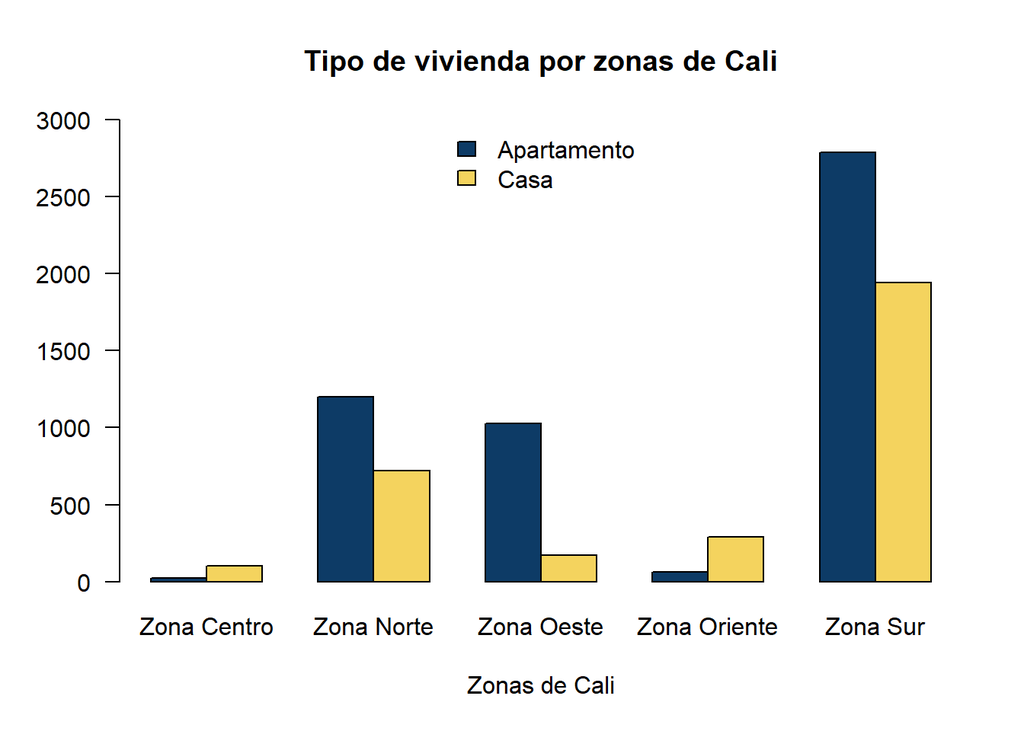

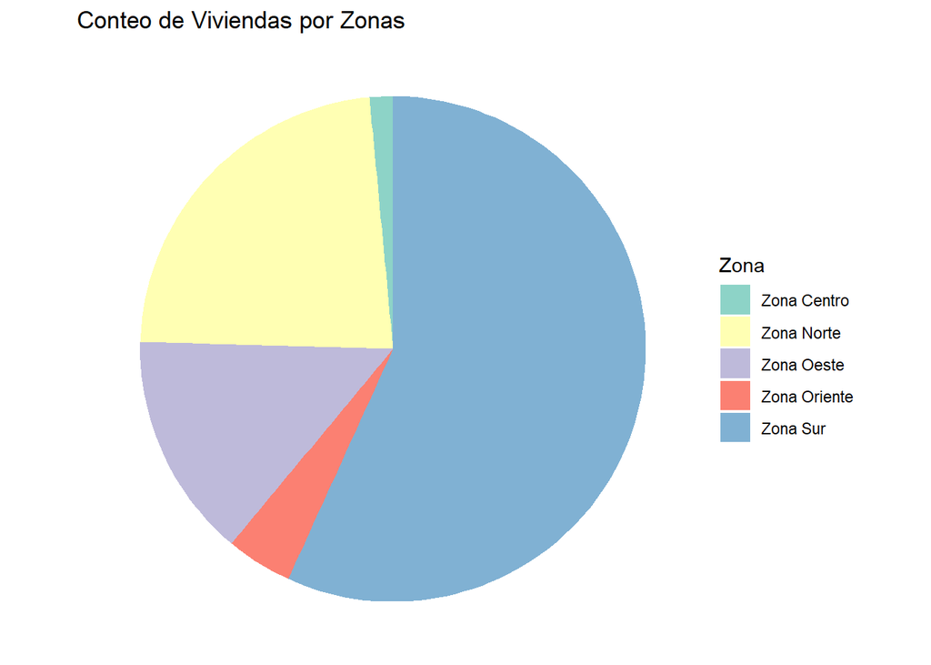

#### 2. Encontrar las características más relevantes de la oferta de vivienda en Cali.

Respecto a las características se puede apreciar que las viviendas van del estrato 3 a 6, donde la mayor cantidad es de estrato 5 y la menor de estrato 3. Respecto al precio se ve que hay una alta concentración de viviendas que valen 500 millones de pesos o menos, el 60% de las viviendas ronda entre los 58 a los 390 millones mientras que el 40% restante es mayor a los 390 millones y llega a los 1999 millones de pesos. En el área construida ocurre algo similar en donde la mayor concentración de viviendas se encentra en el rango menor a 500 metros cuadrados construidos, el 90% tiene 350 metros cuadrados o menos mientras que el 10% restante es mayor a 350 y llega hasta los 1745 metros cuadrados, una distribución aún más desigual que la del precio.

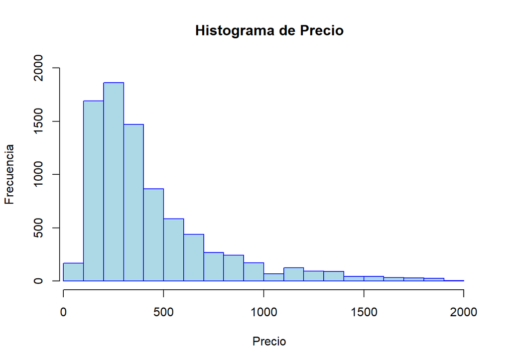

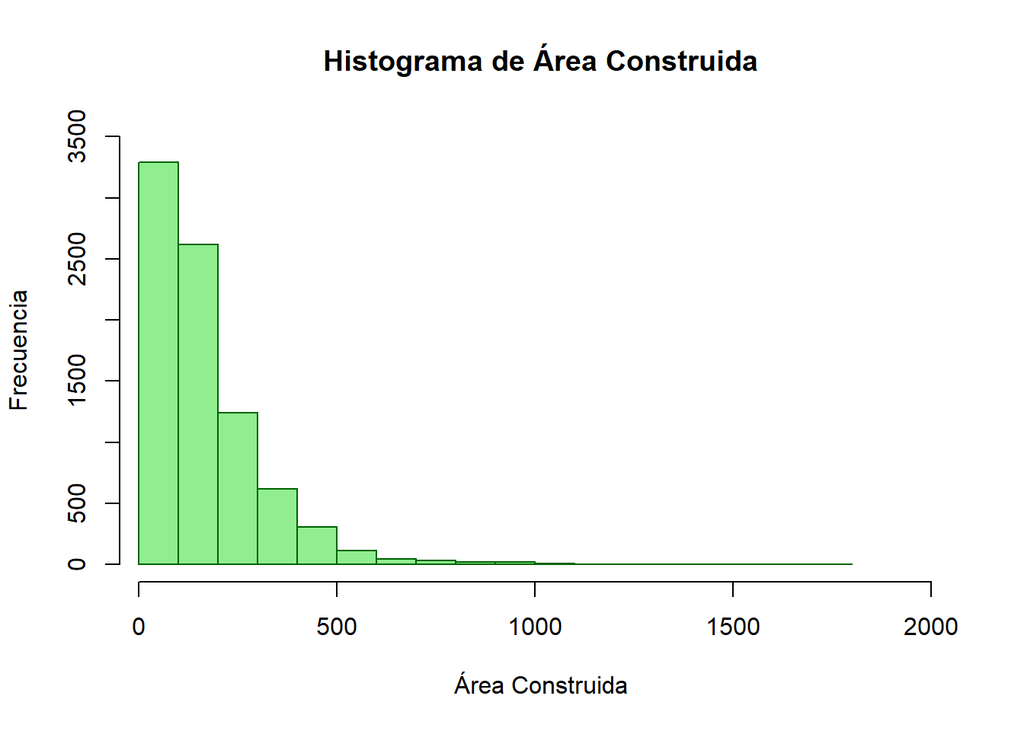

#### 3. Encontrar correlaciones entre las distintas variables.

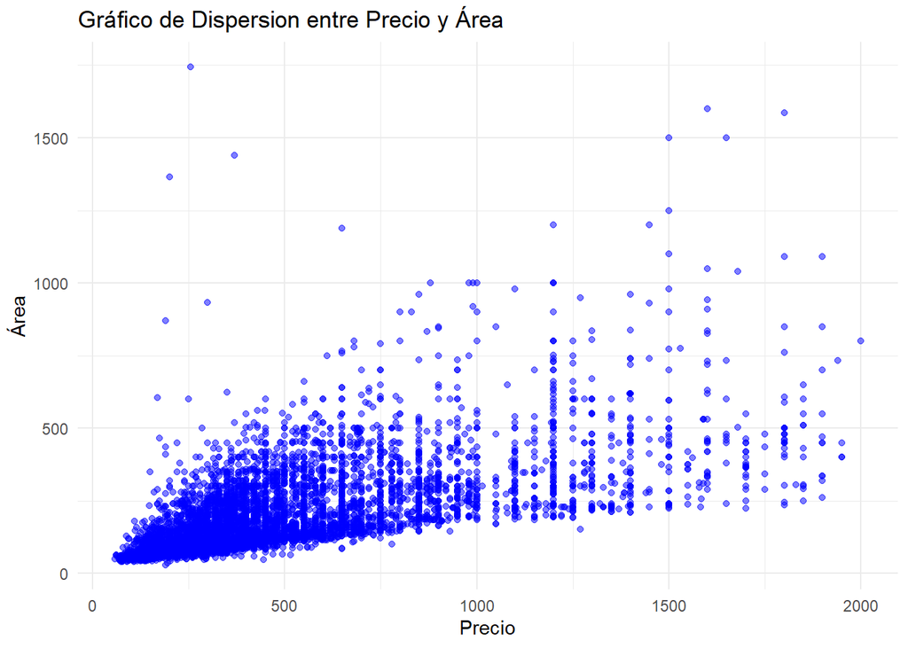

#### 4. Mostrar el precio de las viviendas en distintas zonas de Cali.

El precio de las viviendas en Cali varía dependiendo de la zona y aun en la misma zona el precio tiende a cambiar mucho, en todas las zonas de Cali el precio tiene un coeficiente de variación mayor al 52% por lo que se puede concluir que todas las zonas tienen precios bastante heterogéneos. A pesar de lo anterior es evidente que hay cambios por zona, como que el oeste y el sur tienen viviendas más caras en promedio que el resto de zonas, siendo el oeste la zona con el rango de precios más amplio y el centro con el rango más pequeño, también se ve que en promedio las viviendas más baratas se encuentran en el oriente.

Resumen estadístico del precio por zona

| zona | Minimo | Maximo | Media | Mediana | Rango |
| --- | --- | --- | --- | --- | --- |
| Zona Centro | 100 | 1100 | 309.69 | 297 | 1000 |
| Zona Norte | 65 | 1940 | 345.61 | 300 | 1875 |
| Zona Oeste | 85 | 1999 | 677.58 | 580 | 1914 |
| Zona Oriente | 58 | 1350 | 228.53 | 210 | 1292 |
| Zona Sur | 75 | 1900 | 426.52 | 320 | 1825 |

#### 5. Encontrar patrones e información útil para la toma de decisiones de los directivos de B&C.

Para poder realizar los anteriores metodos y para poder hacer un analisis acertado de la informacion primero fue necesario hacer una limpieza de los datos y darle solucion a datos faltantes.Aquí se muestra como antes del estudio de las viviendas en Cali visualizamos cuantos datos faltaban por variable, luego eliminamos los datos nulos, después eliminamos datos que tenían información repetida (esto se podía apreciar en datos con el mismo id), luego para los datos nulos en piso los reemplazamos por 1 pues asumimos que se puso en nulo en viviendas que no tenían múltiples pisos pero todas deben tener al menos 1, reemplazamos también en parqueaderos los nulos que se asume pusieron porque la vivienda no tiene así que los ponemos en 0, por ultimo visualizamos de nuevo los valores nulos y vemos que ya no queda ninguno. También se hizo un reemplazo en la variable tipo para que todas las viviendas tuvieran el mismo formato y así facilitar el informe estadístico.

```r
faltantes <- colSums(is.na(vivienda_faltantes)) %>%
                 as.data.frame()
faltantes #Visualización de datos faltantes por variable
```

|  | . |
| --- | --- |
| id | 3 |
| zona | 3 |
| piso | 2641 |
| estrato | 3 |
| preciom | 2 |
| areaconst | 3 |
| parquea | 1606 |
| banios | 3 |
| habitac | 3 |
| tipo | 3 |

[output cut: 3 more lines]

```r
data1 <- vivienda_faltantes[!is.na(vivienda_faltantes$id), ] #Eliminamos los datos nulos sin información relevante
data1 <- data1[!duplicated(data1$id), ] #Eliminamos los datos que esten repetidos
data1$piso[is.na(data1$piso)] <- 1# Reemplazamos NA en la variable "piso" por 1
data1$parquea[is.na(data1$parquea)] <- 0# Reemplazamos NA en la variable "parquea" por 0
faltantes <- colSums(is.na(data1)) %>%
                 as.data.frame()
faltantes #Visualización de datos faltantes por variable despues de la limpieza
```

|  | . |
| --- | --- |
| id | 0 |
| zona | 0 |
| piso | 0 |
| estrato | 0 |
| preciom | 0 |
| areaconst | 0 |
| parquea | 0 |
| banios | 0 |
| habitac | 0 |
| tipo | 0 |

[output cut: 3 more lines]

```r
valortipos <- unique(data1$tipo)
valortipos #Quiero ver todos los valores que tiene la variable tipo
```

```
## [1] "Apartamento" "Casa"        "APARTAMENTO" "casa"        "CASA"
## [6] "apto"
```

```r
#Como hay valores que significan lo mismo pero estan escritos de forma distinta los dejaremos todos en un mismo fomrato
data1$tipo[data1$tipo %in% c("APARTAMENTO", "apto")] <- "Apartamento"  # Reemplazamos las variaciones de "Apartamento"
data1$tipo[data1$tipo %in% c("casa", "CASA")] <- "Casa"  # Reemplazamos las variaciones de "Casa"
valordesp <- unique(data1$tipo)
valordesp #Quiero ver todos los valores que tiene la variable tipo despues del cambio
```

```
## [1] "Apartamento" "Casa"
```

## 6. Conclusiones

En las conclusiones a continuación se pretende dejar una interpretación de lo recolectado y recomendaciones para que con esta información los directivos puedan tomar decisiones.  
Se le recomienda a los directivos plantear distintos acercamientos por zonas, a pesar de que muchas viviendas compartan características se ve por ejemplo que en la zona oeste predominan los apartamentos y en general las viviendas son más caras por lo que se le puede ofrecer un servicio personalizado a los clientes con mayor capital y ofrecerles este tipo de viviendas a precios altos, en zonas como el centro en cambio se pueden ofrecer casas más baratas pero en mayor cantidad. No solo esto, sino que también vemos que la cantidad de viviendas es mayor en el sur por lo que se puede explotar más esta zona que tiene aún más casas que el centro y el oriente juntos, así que se puede establecer aquí un nicho de mercado más estable ya que en promedio en el sur las viviendas son más caras que en el resto de las zonas exceptuando la zona oeste. Las variables que muestran un patrón más marcado respecto al precio de la casa son la zona y el área así que se sugiere plantear el precio de las viviendas teniendo esas características en mente además de las que obviamente incrementan el precio tales como el parqueadero, los baños y las habitaciones puesto que existen casas con menos de 500 metros cuadrados las cuales valen más de 1750 millones (aunque esto no es la mayoría por eso se sugiere tener más en cuenta la zona y el área).

## 7. Anexos

En los siguientes anexos se mostraran datos relevantes de los métodos no incluidos en los resultados.

#### 1. Tabla de frecuencias de viviendas por zona.

| Zona | Frecuencia Absoluta | Frecuencia Relativa (%) |
| --- | --- | --- |
| Zona Centro | 124 | 1.49 |
| Zona Norte | 1920 | 23.08 |
| Zona Oeste | 1198 | 14.40 |
| Zona Oriente | 351 | 4.22 |
| Zona Sur | 4726 | 56.81 |

#### 2. Tablas de frecuencias del tipo de vivienda en Cali y de la frecuencia relativa de los tipos de vivienda por zona.

| Tipo | Frecuencia | Frecuencia Relativa (%) |
| --- | --- | --- |
| Apartamento | 5099 | 61.29 |
| Casa | 3220 | 38.71 |

|  | Zona Centro (%) | Zona Norte (%) | Zona Oeste (%) | Zona Oriente (%) | Zona Sur (%) |
| --- | --- | --- | --- | --- | --- |
| Apartamento | 19.35 | 62.4 | 85.89 | 17.66 | 58.95 |
| Casa | 80.65 | 37.6 | 14.11 | 82.34 | 41.05 |

#### 3. Datos adicionales de la dispersión del precio por zona.

Resumen estadístico de dispersión del precio por zona

| zona | Coeficiente de variación(%) | Desviación estandar |
| --- | --- | --- |
| Zona Centro | 52.36 | 162.1479 |
| Zona Norte | 69.69 | 240.8674 |
| Zona Oeste | 57.79 | 391.5828 |
| Zona Oriente | 53.41 | 122.0641 |
| Zona Sur | 75.66 | 322.7229 |

#### 4. Distribución de baños, pisos y habitaciones.

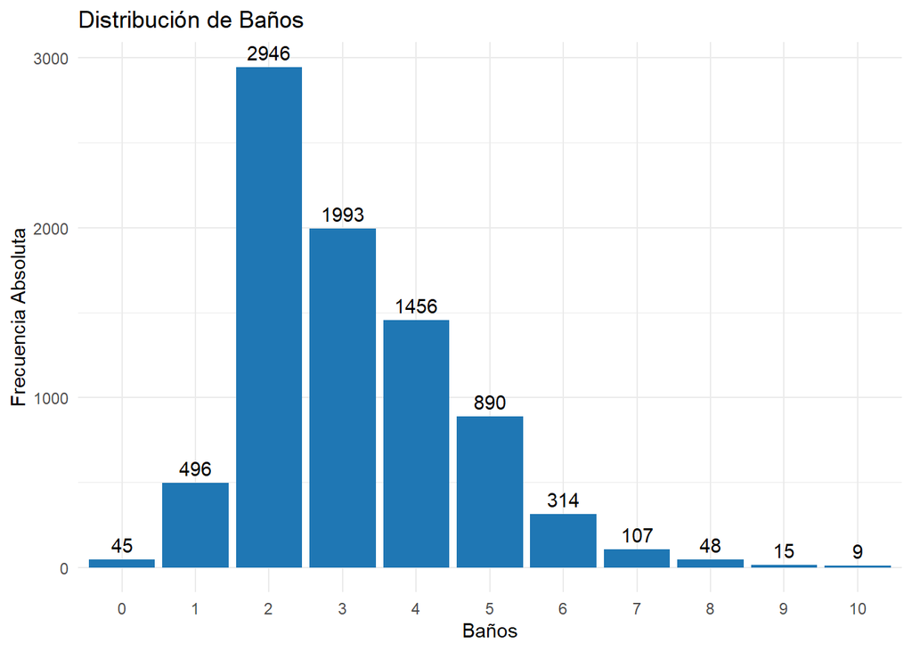

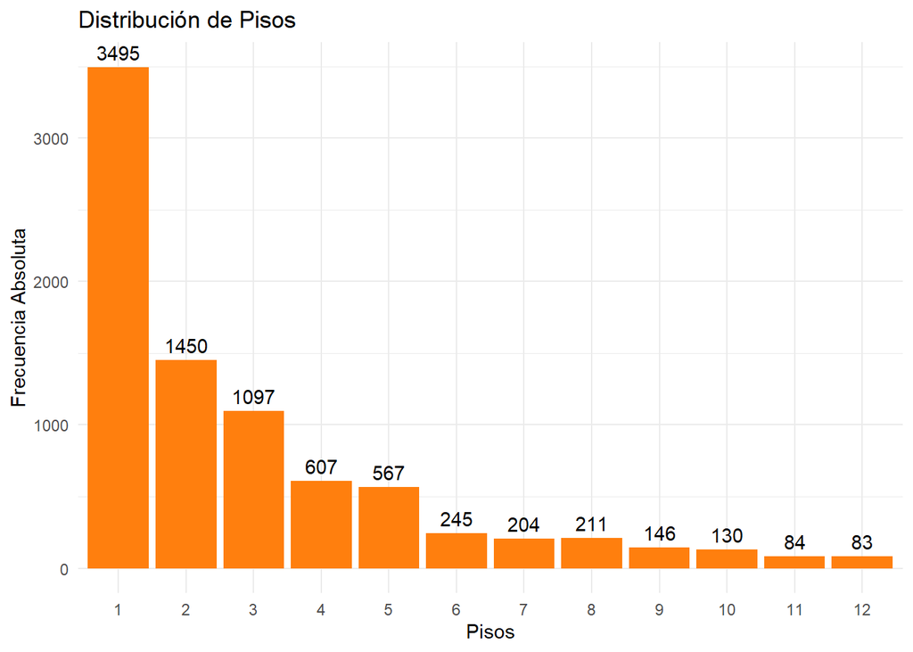

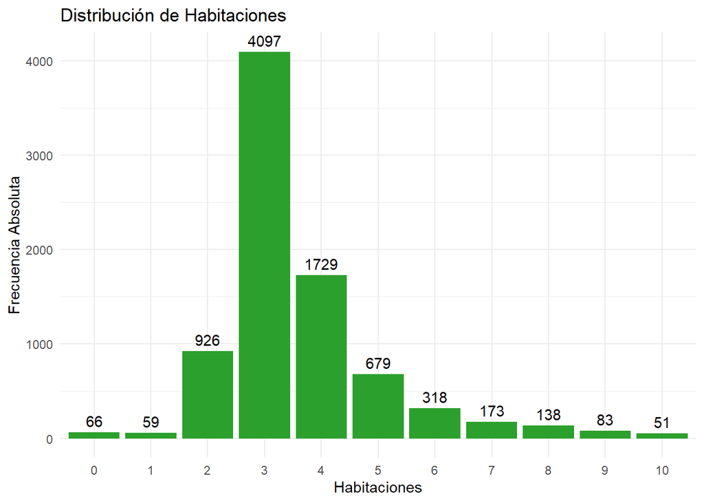

#### 5. Gráfico de barras de viviendas por estrato.

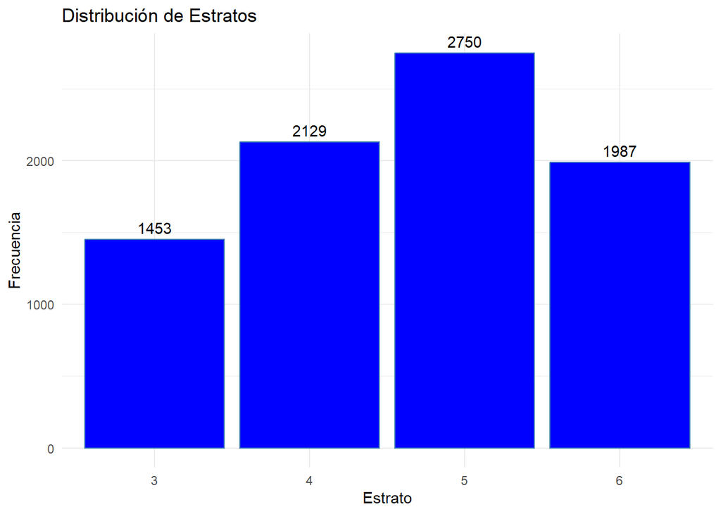

#### 6.Indicadores de posición del precio y el área construida.

| Decil | Mínimo | 0.1 | 0.2 | 0.3 | 0.4 | 0.5 | 0.6 | 0.7 | 0.8 | 0.9 | Máximo |
| --- | --- | --- | --- | --- | --- | --- | --- | --- | --- | --- | --- |
| Precio | 58 | 145 | 190 | 240 | 285 | 330 | 390 | 475 | 610 | 870 | 1999 |

| Decil | Mínimo | 0.1 | 0.2 | 0.3 | 0.4 | 0.5 | 0.6 | 0.7 | 0.8 | 0.9 | Máximo |
| --- | --- | --- | --- | --- | --- | --- | --- | --- | --- | --- | --- |
| Area | 30 | 60 | 73 | 86 | 102 | 123 | 153 | 200 | 258 | 350 | 1745 |